# Apple App Store app analysis

## App Store

The Apple App Store is a digital store that allows its users to download apps for iPhone, iPad, Mac and all the other devices of Apple’s ecosystem.

[figure not shown]

## Dataset description

- Snapshot in a time instant
- 7000+ apps
- Most significant features:
  - **user rating** (mean of the votes of the reviews)
  - **price**
  - **total number of reviews**
  - **category**
  - **size**

## Goal

In this presentation we’re going to explore the dataset and search for a correlation between the app’s rating, price, number of reviews, and category. The next slides will show the findings on this topic.

This is important for app developers as they can use this information to make changes to their app. An app developer could inspect the results of this project in order to find room for improvement.

## Popularity

- The popularity of an **app** is measured by counting the total number of user ratings
- The popularity of a **category** is measured by counting the number of apps that fall into that category

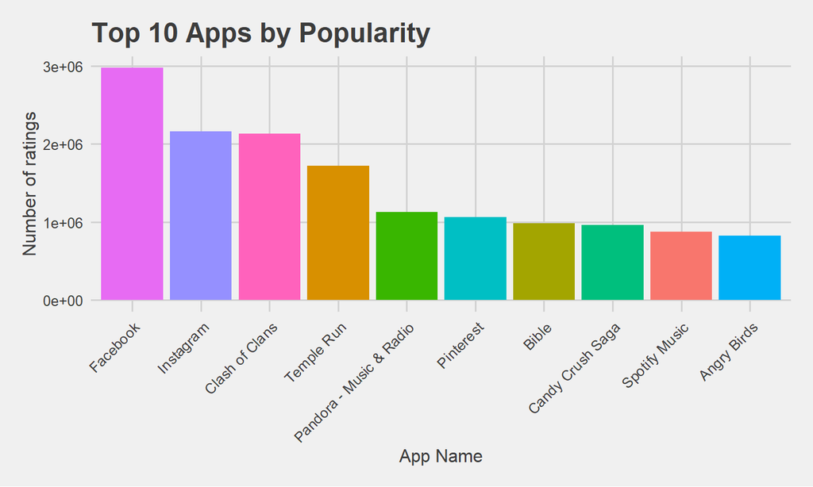

## Distributions of apps in categories

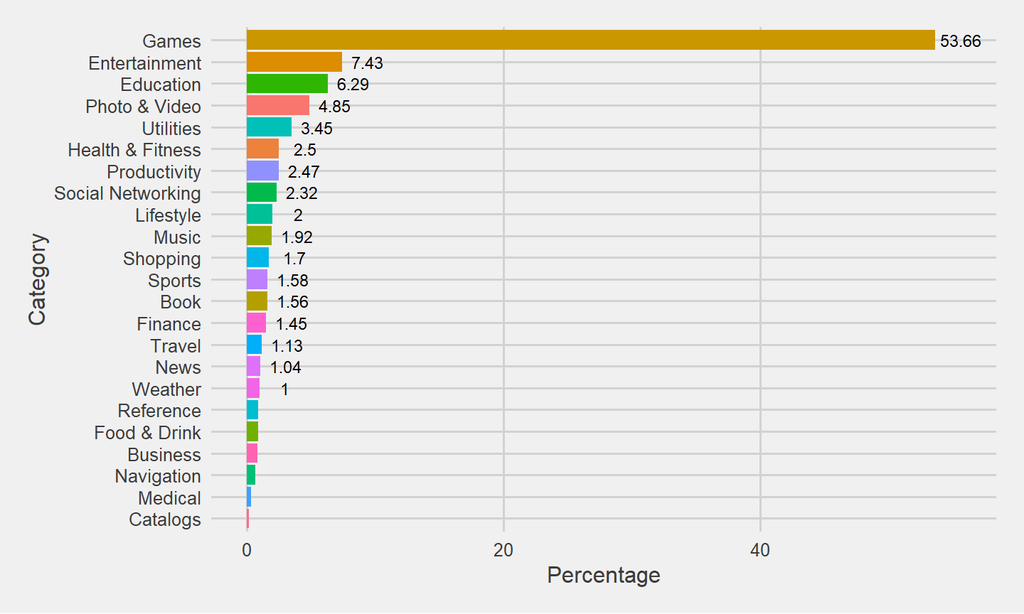

## Top 100 apps categories

- The 5 categories with most apps contain 68 of the top 100 most popular apps
- The `Games` category contains 60 of the top 100 most popular apps
- The `Education` category, despite being one of the 5 categories with most apps in it, does not have any app in the top 100 most popular apps

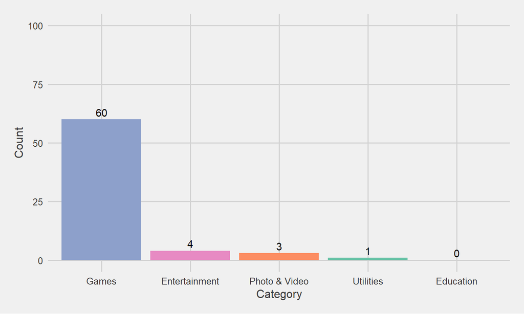

## Categories and prices

- The `Shopping` category contains mostly free apps (99.18%)

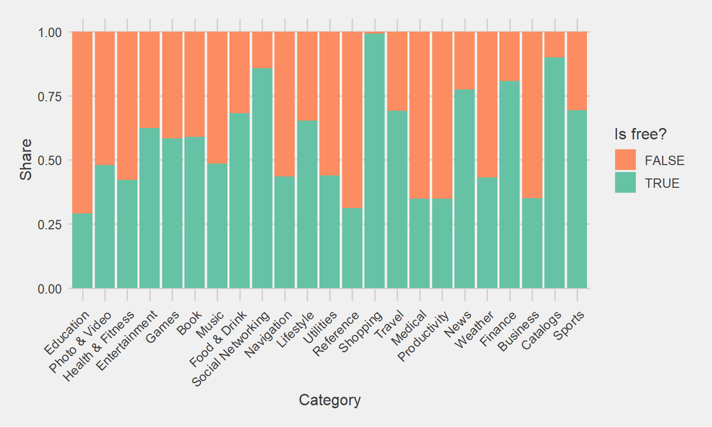

## Categories and prices

- The `Medical` category is by far the category with the highest mean price
- The `Shopping` category, by containing mostly free apps, of course has a low mean (0.02$)

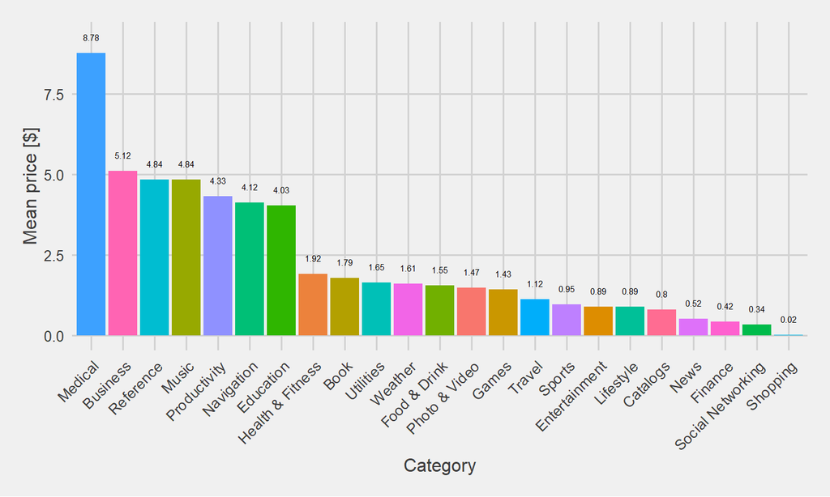

## Distribution of free and paid apps

- Slightly more free apps: **56,36%**
- Balanced amount of free and paid
- Not balanced if we look at the prices: more than half of the apps have a price of 0$

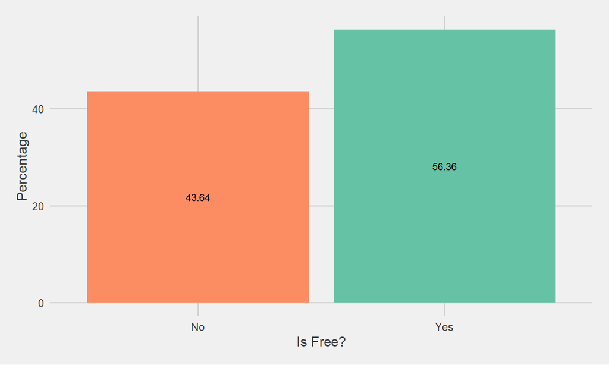

## Free and paid apps

The 56.4% of the apps are free, but things change when the we observe the top 10, 100 and 1000 most popular apps

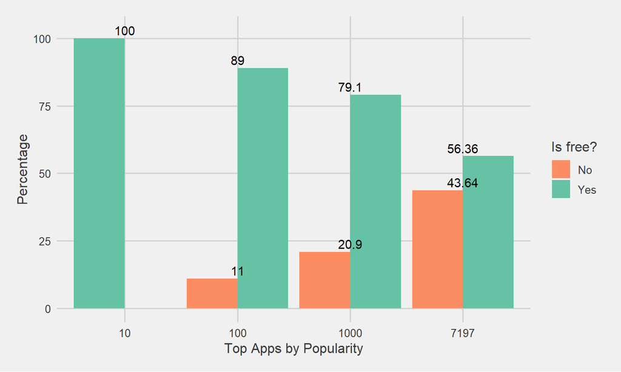

## Price trend

- Price
  - Mean: 1.73$
  - Median: 0$
  - Mode: 0$
- 4.784 apps (66,47%) cost 1$ or less
- 6.759 apps (93,91%) cost 5$ or less
- 7.100 apps (98,65%) cost 10$ or less

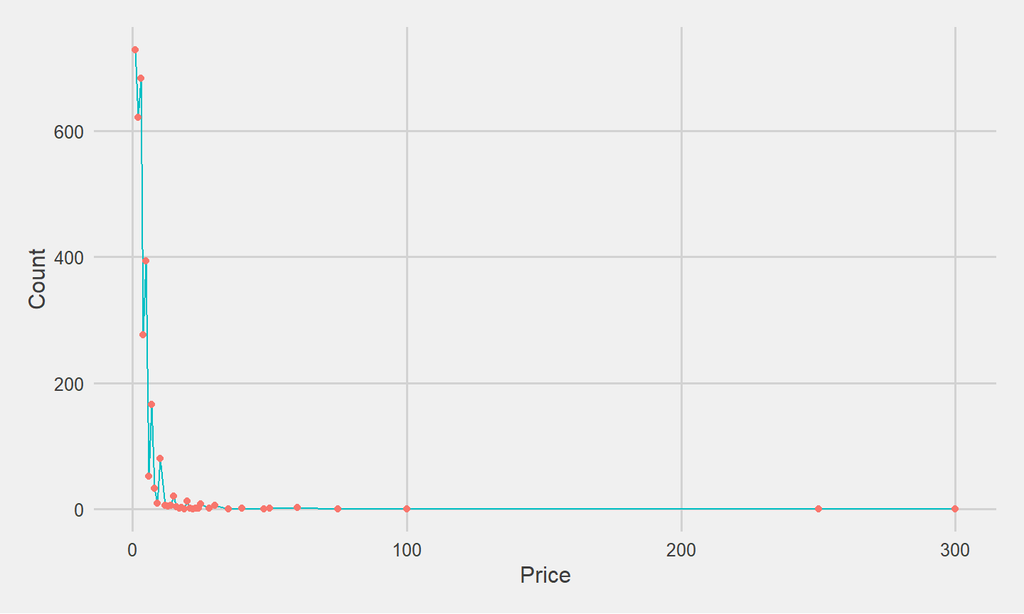

## Popular apps’ rating

- Hypothesis: the more popular an app is, the higher the user rating
- Top 10, 100 and 1000 most popular apps
- The data confirms the hypothesis

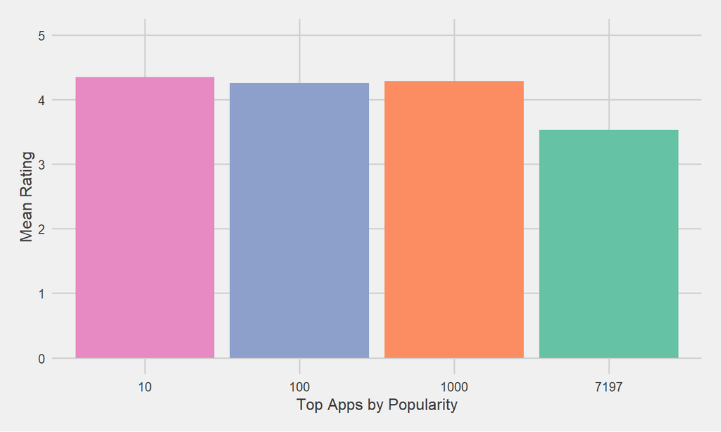

## Distribution of the user rating

- Rating
  - Mean: 3.53
  - Median: 4
  - Mode: 4.5
- General tendency to a high rating

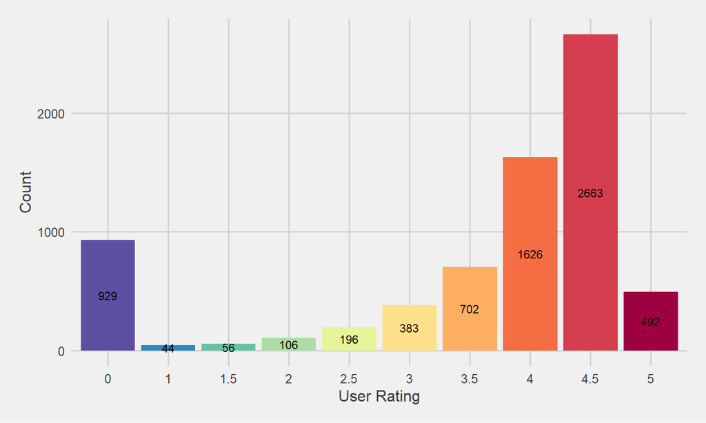

## User rating vs category

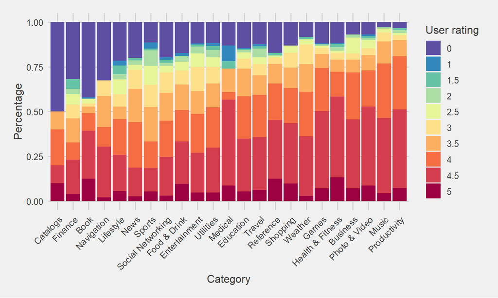

## User rating vs price

- Price goes towards 0 for each user rating

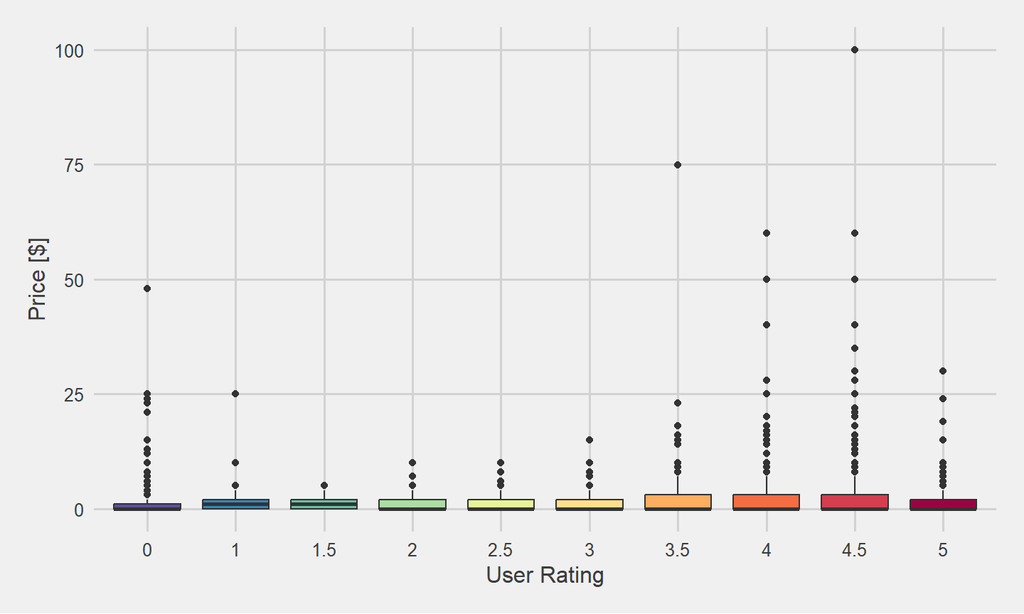

## User rating vs price

- Mean price is higher for apps with high rating

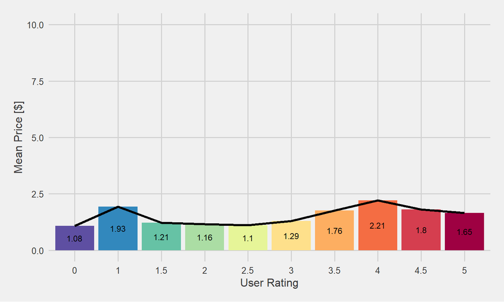

## User rating vs size

- Mean size **199,13 MB**
- Bigger apps are the not rated ones and the ones with higher rating

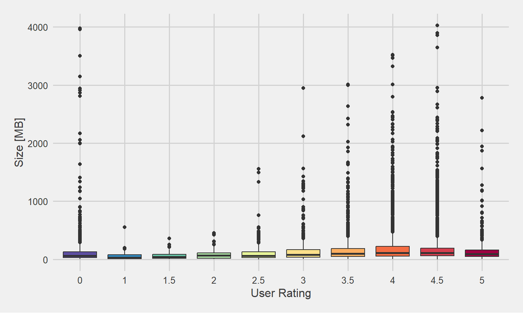

## User rating vs size

- Mean size **199,13 MB**
- Bigger apps are the ones that are not rated and the ones with higher rating

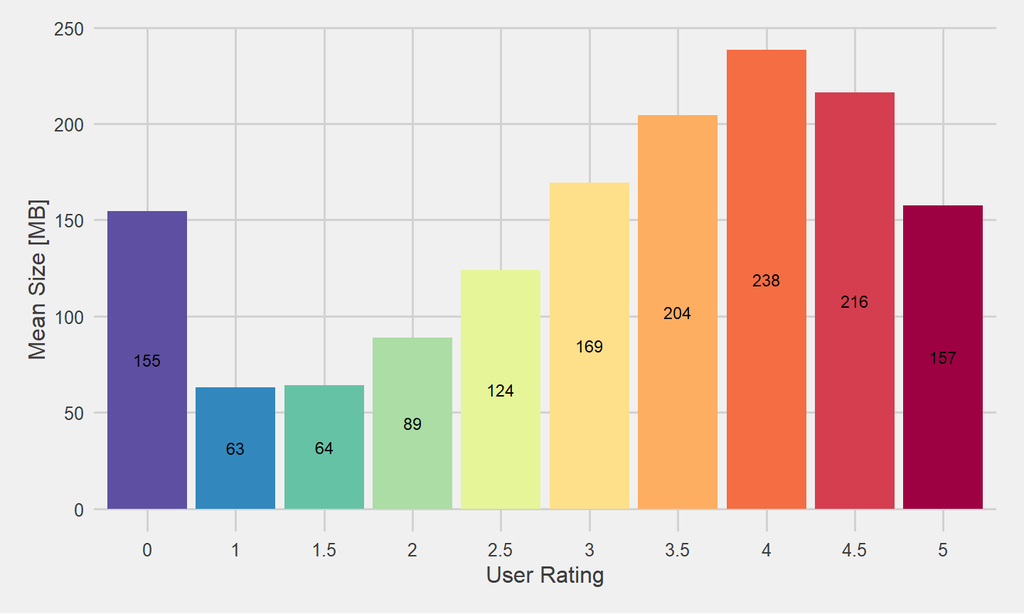

## Rating correlation

- Linear regression model is used
- Searching correlation with `size_bytes`, `price`, `prime_genre`, `rating_count_tot`

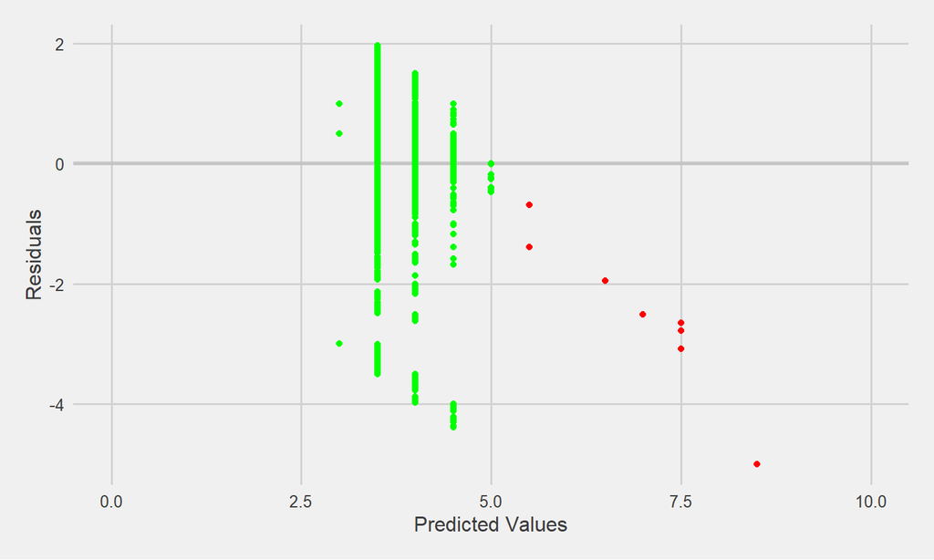

## Conclusions

- Is target variable `user_rating` correlated with `size_bytes` , `price` , `prime_genre` , `rating_count_tot`?
  - R-squared value (0.02) suggests that there is no correlation between them
- Even if in the preliminary observation a correlation can be found, the analytical process suggests the opposite

### Future possibilities

- Measure the popularity feature adding the number of downloads, which this dataset misses
- Search for a correlation between the rating and the number of downloads (still, assuming this data is available)

Thank you for your attention!